# Influencia del COVID-19 en los mejores equipos de la MLB

## Importacion de Librerias Necesarias.

```r
library(dplyr)
library(lubridate)
```

```r
library(ggplot2)
```

## Importacion de CSV.

En este apartado, importamos el CSV con la informacion de contagios por **Condado**.

```r
url = "https://raw.githubusercontent.com/nytimes/covid-19-data/master/us-counties.csv"
covidByCounty <- read.csv(file = url)
```

## Seleccion de Condados.

De acuerdo a una investigacion, observamos que los dos equipos finalistas por liga fueron:

- American League
  - Tampa Bay. – Hillsborough County
  - Houston Astros – Harris County.
- National League.
  - Los Angeles Dodgers – Los Angeles County.
  - Atlanta Braves Fulton County.

```r
str(covidByCounty)
```

```
## 'data.frame':    1001656 obs. of  6 variables:
##  $ date  : chr  "2020-01-21" "2020-01-22" "2020-01-23" "2020-01-24" ...
##  $ county: chr  "Snohomish" "Snohomish" "Snohomish" "Cook" ...
##  $ state : chr  "Washington" "Washington" "Washington" "Illinois" ...
##  $ fips  : int  53061 53061 53061 17031 53061 6059 17031 53061 4013 6037 ...
##  $ cases : int  1 1 1 1 1 1 1 1 1 1 ...
##  $ deaths: int  0 0 0 0 0 0 0 0 0 0 ...
```

```r
counties <- filter(covidByCounty, county == "Harris" | county == "Los Angeles" | county == "Hillsborough" | county == "Fulton")
```

## Tratamiento de Datos:

En este apartado, seleccionamos los datos necesarios para realizar nuestro analisis. Renombramos nuestras variables y las mutamos para que opuedan ser utilizadas.

```r
counties <- select(counties, date,county,cases, fips)
counties <- mutate(counties, date = as.Date(date,"%Y-%m-%d"))
str(counties)
```

```
## 'data.frame':    4192 obs. of  4 variables:
##  $ date  : Date, format: "2020-01-26" "2020-01-27" ...
##  $ county: chr  "Los Angeles" "Los Angeles" "Los Angeles" "Los Angeles" ...
##  $ cases : int  1 1 1 1 1 1 1 1 1 1 ...
##  $ fips  : int  6037 6037 6037 6037 6037 6037 6037 6037 6037 6037 ...
```

Posteriormente, filtramos por la fecha de inicio de la temporada y la fecha de conclusion.

- Start Date:
  - Jul 23, 2020.
- End Date:
  - Sept, 29, 2020.

```r
counties <- filter(counties, date >= "2020-07-23" & date <= "2020-09-29")
```

Una vez que ya hemos pre filtrado nuestra informacion, procedemos a crear nuestros Dataframes por Condado.

### Tampa Bay Rays

```r
TampaCounty <- filter(counties, county == "Hillsborough" & fips == 12057)
TampaCounty <- mutate(TampaCounty, NewCases = c(1, diff(cases))) # Nuevos infectados por día
TampaCounty <- TampaCounty %>% group_by(date=floor_date(date, "7 days"),county,) %>%
   summarize(NewCases=sum(NewCases))
head(TampaCounty)
```

| date | county | NewCases |
| --- | --- | --- |
| 2020-07-22 | Hillsborough | 2392 |
| 2020-07-29 | Hillsborough | 1293 |
| 2020-08-01 | Hillsborough | 2749 |
| 2020-08-08 | Hillsborough | 1829 |
| 2020-08-15 | Hillsborough | 1599 |
| 2020-08-22 | Hillsborough | 1281 |

### Los Angeles Dodgers

```r
DodgersCounty <- filter(counties, county == "Los Angeles")
DodgersCounty <- mutate(DodgersCounty, NewCases = c(1, diff(cases))) # Nuevos infectados por día
DodgersCounty <- DodgersCounty %>% group_by(date=floor_date(date, "7 days"),county,) %>%
   summarize(NewCases=sum(NewCases))
head(DodgersCounty)
```

| date | county | NewCases |
| --- | --- | --- |
| 2020-07-22 | Los Angeles | 11795 |
| 2020-07-29 | Los Angeles | 9839 |
| 2020-08-01 | Los Angeles | 15686 |
| 2020-08-08 | Los Angeles | 14526 |
| 2020-08-15 | Los Angeles | 10361 |
| 2020-08-22 | Los Angeles | 9404 |

### Houston Astros

```r
AstrosCounty <- filter(counties, county == "Harris")
AstrosCounty <- mutate(AstrosCounty, NewCases = c(1, diff(cases))) # Nuevos infectados por día
AstrosCounty <- AstrosCounty %>% group_by(date=floor_date(date, "7 days"),county,) %>%
   summarize(NewCases=sum(NewCases))
head(AstrosCounty)
```

| date | county | NewCases |
| --- | --- | --- |
| 2020-07-22 | Harris | 67126 |
| 2020-07-29 | Harris | 5304 |
| 2020-08-01 | Harris | 10219 |
| 2020-08-08 | Harris | 7391 |
| 2020-08-15 | Harris | 6084 |
| 2020-08-22 | Harris | 6430 |

### AtlantaBraves

```r
BravesCounty <- filter(counties, county == "Fulton" & fips == 13121)
BravesCounty <- mutate(BravesCounty, NewCases = c(1, diff(cases))) # Nuevos infectados por día
BravesCounty <- BravesCounty %>% group_by(date=floor_date(date, "7 days"),county,) %>%
   summarize(NewCases=sum(NewCases))
head(BravesCounty)
```

| date | county | NewCases |
| --- | --- | --- |
| 2020-07-22 | Fulton | 1810 |
| 2020-07-29 | Fulton | 1164 |
| 2020-08-01 | Fulton | 2001 |
| 2020-08-08 | Fulton | 1954 |
| 2020-08-15 | Fulton | 1774 |
| 2020-08-22 | Fulton | 1211 |

## Graficas de Resultados Individuales por Condado

### Contagios de COVID en el Condado donde Juega Tampa Bay

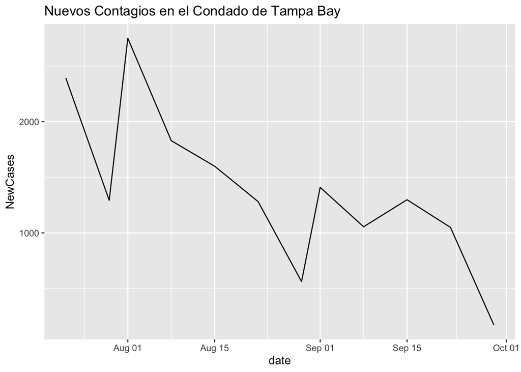

```r
ggplot(TampaCounty, aes(x=date, y = NewCases)) +
  geom_line() +ggtitle("Nuevos Contagios en el Condado de Tampa Bay")
```

### Contagios de COVID en el Condado donde Juegan Los Angeles Dodgers

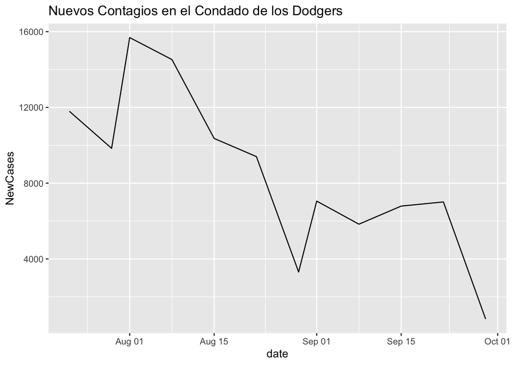

```r
ggplot(DodgersCounty, aes(x=date, y = NewCases)) +
  geom_line() +ggtitle("Nuevos Contagios en el Condado de los Dodgers")
```

### Contagios de COVID en el Condado donde Juega Atlanta Braves

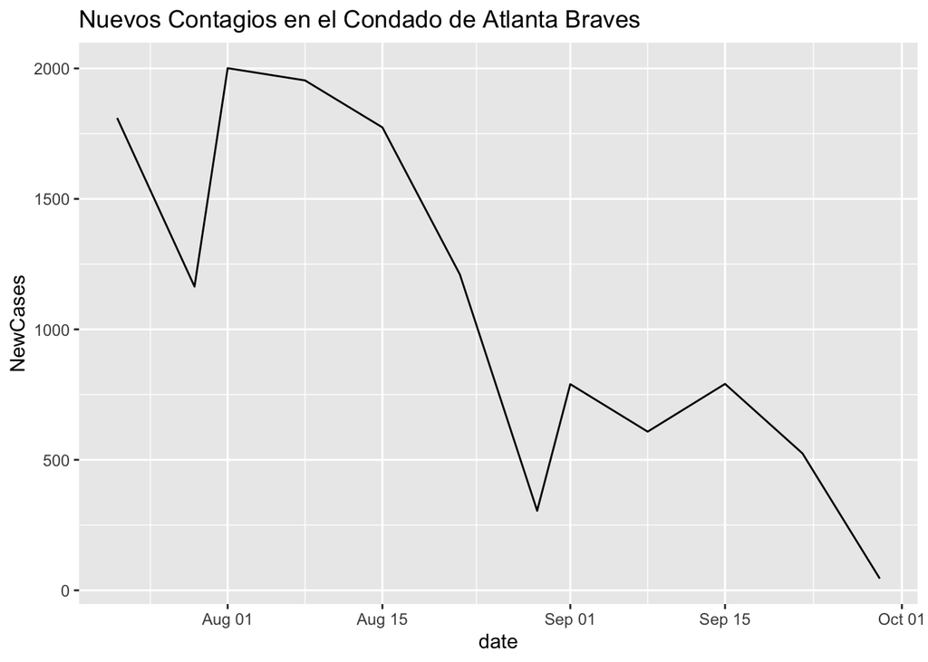

```r
ggplot(BravesCounty, aes(x=date, y = NewCases)) +
  geom_line() +ggtitle("Nuevos Contagios en el Condado de Atlanta Braves")
```

### Contagios de COVID en el Condado donde Juegan los Houston Astros

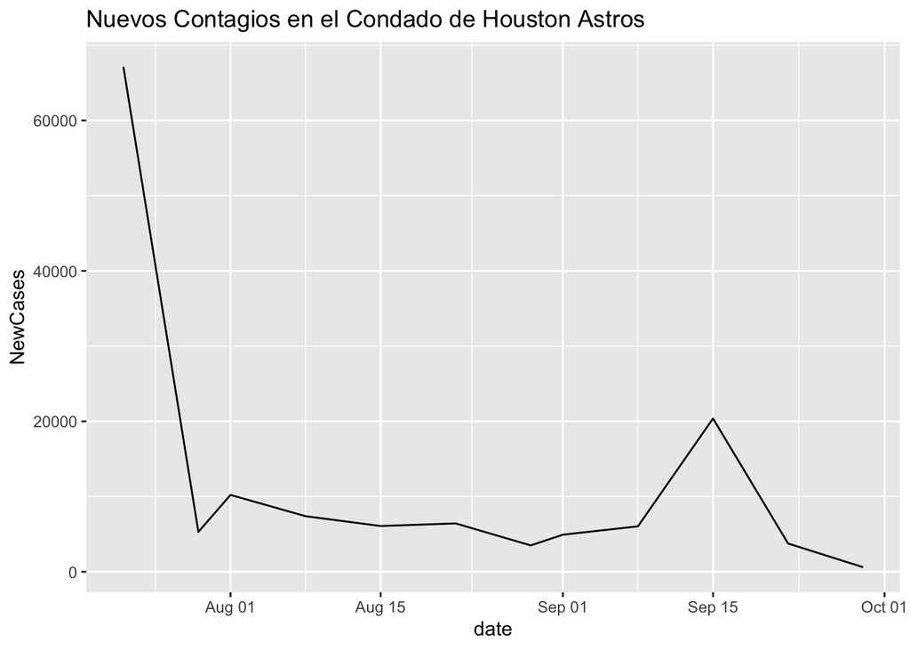

```r
ggplot(AstrosCounty, aes(x=date, y = NewCases)) +
  geom_line() +ggtitle("Nuevos Contagios en el Condado de Houston Astros")
```

## Graficas de los Resultados de contagios de COVID de los 4` Condados Para poder realizar esta grafica es necesario, agrupar los 4 resultados en un solo dataframe, despues de esto graficamos.

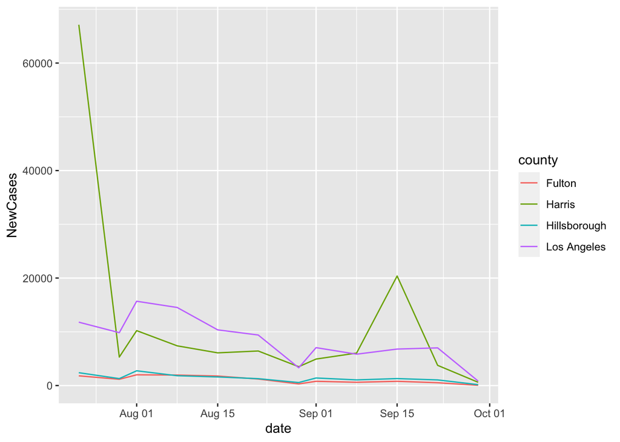

```r
mlbCounties <-  rbind(AstrosCounty,BravesCounty, DodgersCounty, TampaCounty)


ggplot(mlbCounties) + geom_line(aes(x = date, y = NewCases, colour=county))
```

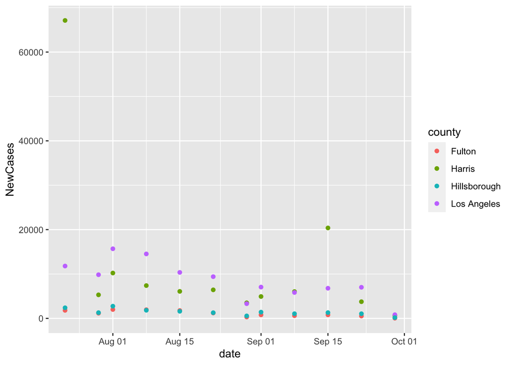

```r
ggplot(mlbCounties) + geom_point(aes(x = date, y = NewCases, colour=county))
```